# MIDI-MT - Lighting control module

MIDI-MT Documentation in English

## Lighting control

- Overview of the use of the DMX512 and ArtNet protocols
- Settings for the lighting control module
- Control Binding Settings
- Configuration file
- Repeaters, repeaters and protocol converters
  - Arduino based repeater “DMX512”, “ArtNet”, “MQTT”

Currently, at reasonable prices, a large number of lighting equipment that support control via the **DMX512** protocol has become available.

The **DMX512** protocol is designed to control lighting fixtures. It allows you to control `512` channels simultaneously via one three-wire communication line. Depending on the capabilities of the lighting device, you can change the color, brightness, position of the light beam, switching effects and many other characteristics. As a rule, several channels are used on one lighting fixture. Several devices switched on simultaneously allow using the **DMX512** control protocol to create light patterns and design elements of varying complexity.

**The ArtNet** protocol is a network version of the **DMX512** protocol. Distributed over a local network by sending to broadcast addresses. In this case, the final equipment must support the **ArtNet** protocol, or a gate must be installed to convert to the **DMX512** protocol.

**MIDI-MT** supports both of these protocols, both simultaneous and separate operation is possible. Support for both standard 8-bit channels and 16-bit channels has been implemented. They can be used simultaneously, but when designing a network, it must be taken into account that a 16-bit channel takes the place of two 8-bit channels. For example, if you assign a device with four 16-bit DMX channels address 10, then the next free DMX address will be number 18 and not 14.

You can read more about the protocol on the website [dmx-512.ru](https://dmx-512.ru/wiki/dmx_512).

### Settings for the lighting control module

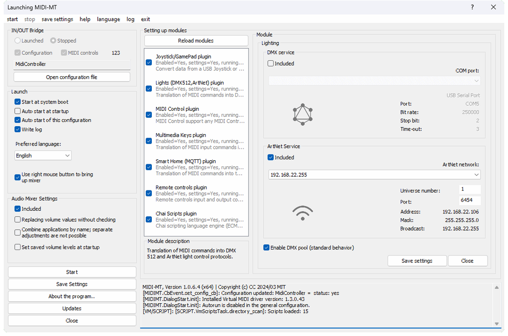

Allows you to control lighting devices and equipment using the **DMX512** and **ArtNet** protocols.

- Selecting “**COM Port**” means selecting the serial port to which the DMX controller is connected. If necessary, the port parameters can be changed in the configuration file by editing.
- Selecting “**ArtNet network**” will allow you to determine on which interface broadcast packets will be sent via the ArtNet protocol.
- The **Universe Number** field defines the addressing of the “universe” for the ArtNet protocol.
- Selecting “**Port**” indicates which port ArtNet data should be sent to, the default port number is `6454`.
- The “**Enable DMX pool**” option, although it is a standard behavior, is not recommended to be enabled when using the ArtNet protocol, as it creates a “network storm”, increasing the load on the local network. If your lighting equipment works without this option, do not use it.

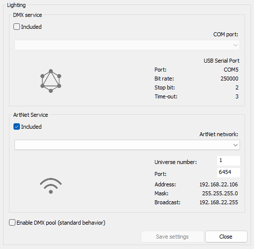

### Control Binding Settings

You can assign 8 or 16 bit channels in the configuration editor. To assign a channel, select the required item in the `Control refers to light control`:

- `Channel "8 bit" (standard)`, group number “251”
- `Channel "16 bit" (extended)`, group number “250”

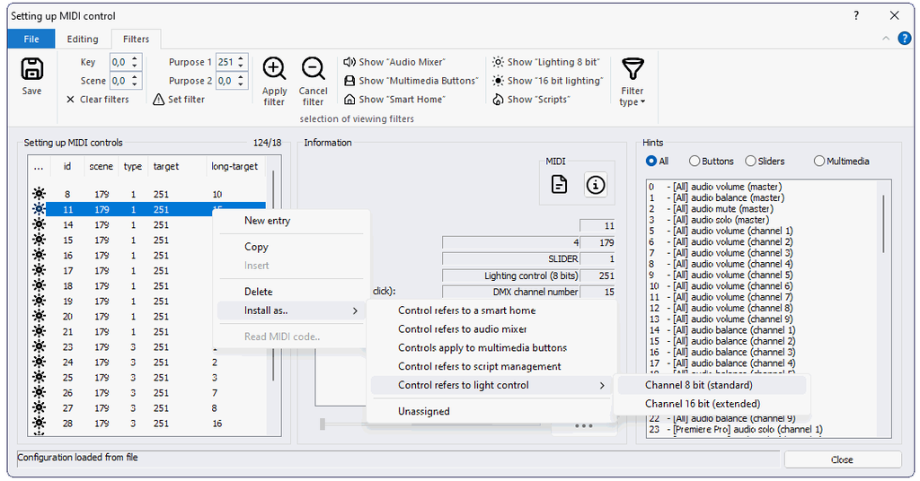

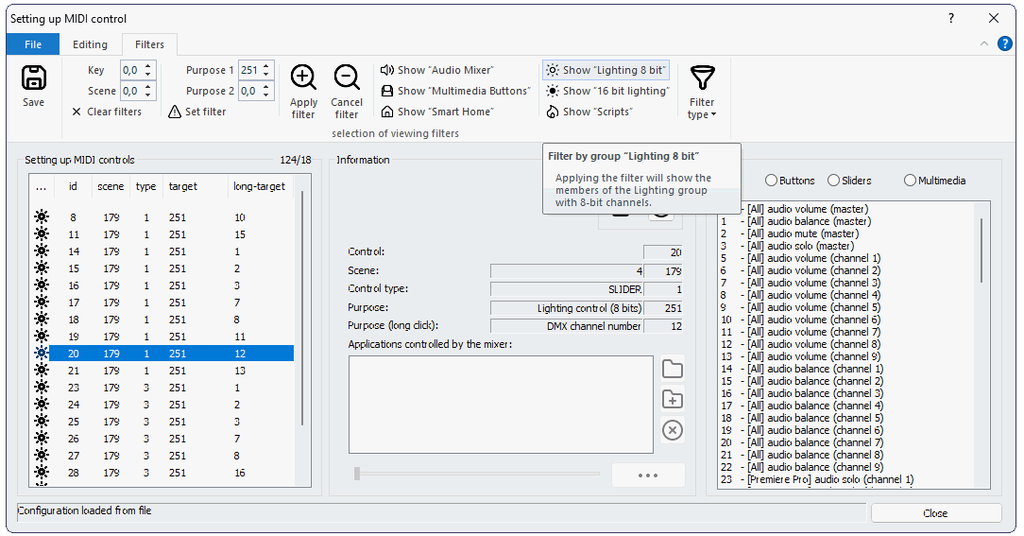

#### Configuration file

It is also possible to edit the configuration file in any editor you are familiar with. The main section of lighting control settings looks like this:

```yaml
    ...
    },
    "lights": {
        "pool": false,
        "dmx": {
          "enable": false,
          "port": 5,
          "baudrate": 250000,
          "stopbits": 2,
          "timeout": 3,
          "name": "USB Serial Port"
        },
        "artnet": {
          "enable": true,
          "port": 6454,
          "universe": 1,
          "ip": "192.168.22.1",
          "mask": "255.255.255.0",
          "broadcast": "192.168.22.255"
        }
    },
    "units":[ ...
          // group 251 - channels with 8-bit resolution.
          // group 250 - channels with a resolution of 16 bits.
          // target = group 251 or 250, longtarget = DMX address of the channel on the device
        {"scene":179,"id":14,"type":1,"target":251,"longtarget":5,"onoff":"false","value":11},
        {"scene":179,"id":15,"type":1,"target":251,"longtarget":6,"onoff":"false","value":33},
        {"scene":179,"id":16,"type":1,"target":251,"longtarget":7,"onoff":"false","value":22},
    ... ]
```

### Repeaters, repeaters and protocol converters

To implement the integration of **ArtNet**, **MQTT** and **DMX512** network technologies into a single lighting control system, you can use not only equipment from well-known manufacturers. It is much cheaper to use `Arduino`-like boards for these purposes that support `WiFi` technology, designed on `ESP` chipsets, for example `ESP8266`, `ESP32`, etc.

At the same time, it turns out to get a device with maximum capabilities at a minimum price. The budget of such a device will cost about the cost of one track lamp, in other words, its cost will be approximately `10-15%` of the price of similar branded equipment.

One of these designs, which serves to expand the coverage of a network of controlled devices, runs under the control of the **MIDI-MT** program, for which it was specially developed. Simplicity of execution and the wide availability of electronic components make it universal. This is a “repeater” that collects control information about the switching status of lighting fixtures from **the ArtNet** and **MQTT** networks, then the information is summarized and transmitted via the **DMX** protocol to the wired network, through which the actual lighting control occurs. Use requires the presence of a wired **DMX512** network and a connection point to it.

The repeater can be connected to a **DMX512** network consisting of one segment. If the control network is divided into unconnected segments, you can install “repeaters” in each network segment, thereby combining them into a single network. At the same time, the distance of the segments from each other does not matter; it is important that all “repeaters” are connected to a single local network, which implies control via the **ArtNet** protocol. If it is not possible to provide all “repeaters” with a single local network, you can use control via the **MQTT** protocol. The standard operating mode **of MIDI-MT** is the simultaneous use of **the ArtNet** and **MQTT** protocols to generate an outgoing DMX stream.

In each lighting network control segment where a “repeater” is installed, it becomes the “Master”, with **MQTT** control signals taking precedence over **ArtNet** signals. If the source was enabled using **MQTT** control, it can only be disabled by it. This applies to any adjustments, both on and off, and to adjusting the brightness or changing the color. On the contrary, if the lighting fixture was turned on by signals from **an ArtNet** source, further control can be taken over by control signals via the **MQTT** protocol.

You can read more about multi-protocol “repeaters” and “endpoints” here.